# hw2_edited

```python
%matplotlib inline
from __future__ import division
#import numpy, pandas, and matplotlib
import pandas as pd
import numpy as np
import matplotlib.pyplot as plt
from matplotlib.colors import ListedColormap
#import scikitlearn
from sklearn import neighbors, datasets, feature_selection
from sklearn.datasets import load_iris
from sklearn.cross_validation import train_test_split, cross_val_score, KFold
```

**Question 1.** Implement KNN classification, using the sklearn package. We learned how to do this in class. See also: http://scikit-learn.org/stable/modules/neighbors.html#nearest-neighbors-classification

```python
#Load in the data
iris = datasets.load_iris()
iris_df = pd.DataFrame(iris.data, columns=iris.feature_names)
iris_df.head()
#iris_df.describe()
```

|  | sepal length (cm) | sepal width (cm) | petal length (cm) | petal width (cm) |
| --- | --- | --- | --- | --- |
| 0 | 5.1 | 3.5 | 1.4 | 0.2 |
| 1 | 4.9 | 3.0 | 1.4 | 0.2 |
| 2 | 4.7 | 3.2 | 1.3 | 0.2 |
| 3 | 4.6 | 3.1 | 1.5 | 0.2 |
| 4 | 5.0 | 3.6 | 1.4 | 0.2 |

```python
# Various variables we'll need to set intially.
n_neighbors = range(1, 51, 2)
#print type(n_neighbors)
print n_neighbors
```

```
[1, 3, 5, 7, 9, 11, 13, 15, 17, 19, 21, 23, 25, 27, 29, 31, 33, 35, 37, 39, 41, 43, 45, 47, 49]
```

```python
# Create the training (and test) set using scikit-learn's train_test_split function
X_train, X_test, y_train, y_test = train_test_split(iris.data, iris.target, test_size=0.2, random_state=12)
```

```python
# Loop through each neighbors value from 1 to 51 and append the scores
scores_q1 = []
for n in n_neighbors:
    clf = neighbors.KNeighborsClassifier(n)
    clf.fit(X_train, y_train)
    scores_q1.append(clf.score(X_test, y_test))
```

```python
scores_ndarray = np.array(scores_q1)
print "Mean score of {} scenarios (odd numbered neighbors from 1 to 51) is {:.2%}".\
    format(len(n_neighbors),scores_ndarray.mean())
```

```
Mean score of 25 scenarios (odd numbered neighbors from 1 to 51) is 94.27%
```

**Question 2.** Use the sklearn package to implement cross-validation for your classifier. Use 5 folds for your cross-validation. See also: http://scikit-learn.org/stable/modules/cross_validation.html#

```python
from sklearn.cross_validation import cross_val_score
```

```python
n_neighbor = 6
clf = neighbors.KNeighborsClassifier(n_neighbor, weights='uniform')
clf.fit(iris.data, iris.target)
scores = cross_val_score(clf, iris.data, iris.target, cv=5)
```

```python
print scores
print scores.mean()
```

```
[ 0.96666667  1.          0.96666667  0.96666667  1.        ]
0.98
```

**Question 3.** Use your KNN classifier and cross-validation code from (1) and (2) above to determine the optimal value of K (number of nearest neighbors to consult) for this Iris dataset. Hint: This hyperparameter will be a number between 1 and 150.

```python
scores_for_dif_k_values = []
for k in range(1,121):
    clf = neighbors.KNeighborsClassifier(k, weights='uniform')
    fold_scores = cross_val_score(clf, iris.data, iris.target, cv=KFold(len(iris.data), n_folds=5, shuffle=True, random_state=0))
    scores_for_dif_k_values.append(fold_scores.mean())
max_k = np.argmax(scores_for_dif_k_values)
print "Optimal value of K: {}".format(max_k+1)
print "K of {} has {} accuracy".format(max_k+1, scores_for_dif_k_values[max_k])
```

```
Optimal value of K: 11
K of 11 has 0.966666666667 accuracy
```

**Question 4.** Using matplotlib, plot classifier accuracy versus the hyperparameter K for a range of K that you consider interesting. Explain in words what you are seeing.

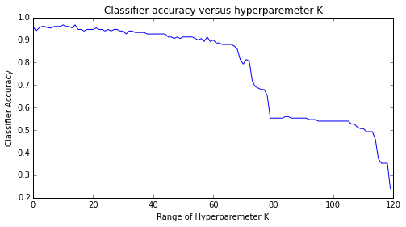

```python
fig = plt.figure(figsize = (8, 4))
ax = fig.add_subplot(1,1,1)
ax.plot(scores_for_dif_k_values)

plt.title('Classifier accuracy versus hyperparemeter K')
plt.xlabel('Range of Hyperparemeter K')
plt.ylabel('Classifier Accuracy')

plt.show()
```

**Question 5.** Now, write your own implementation of cross-validation in Python without using the cross-validation methods from sklearn. Cross validation is a very important concept. Implementing it yourself in Python is the best way to learn and understand it. Compare the results of your cross-validation code with your results using the cross-validation in sklearn.

```python
# 1. The code below first loads and shuffles the iris data set
# 2. Next it separates the iris data set into 5 folds
# 3. Last, it calls a function "find_optimal_k" which loops through \
#   all possible k nearest neighbor values (given a certain number \
#   of folds) and implements KNN and cross-validation for each k value. \
#   The function returns the k value that had the highest accuracy score
##############################################
#Note: For cross-validation, we will use 5 folds
cv_folds = 5
##############################################
#Load iris data set into dataframe and shuffle
iris = datasets.load_iris()
iris_df2 = pd.DataFrame(iris.data, columns=iris.feature_names)
iris_df2['Target'] = iris.target #add column to dataframe with target values
iris_df2_values = iris_df2.values #create ndarray of values
np.random.shuffle(iris_df2_values) #shuffle all rows in the iris values ndarray
iris.feature_names.append('Target') #add target column to feature names in iris data set
iris_df2_shuffled = pd.DataFrame(iris_df2_values, columns=iris.feature_names)
###############################################
#take shuffled array and convert it to five subsets (one for each fold)
subset_1 = iris_df2_values[:30,:]
subset_2 = iris_df2_values[30:60,:]
subset_3 = iris_df2_values[60:90,:]
subset_4 = iris_df2_values[90:120,:]
subset_5 = iris_df2_values[120:150,:]
subset_list = [subset_1,subset_2,subset_3,subset_4,subset_5]
##############################################
# Below is a function that creates and adds to a list called
# "scores_for_dif_k_values" which keeps track of the mean KNN score
# for each k nighbor value tested. This mean knn score is to be derived
# from the average of all cross validation fold scores obtained for each
# specific k. The k with the highest score (found with argmax) is the
# optimal k for this arrangement of the iris data set.
def find_optimal_k(iris_df2, subset_list, cv_folds):
    scores_for_dif_k_values = np.array([])
    #create variables to keep track of dataset length, fold lengths and highest
    #k parameter possible given size of data set and number of cv folds
    dataset_length = len(iris_df2)
    cv_fold_length = dataset_length / cv_folds
    highest_k = int(dataset_length - cv_fold_length)
    #loop through each k value possible (given the number of folds)
    for k in range(1,highest_k):
        folds_scores = np.array([])
        for current_subset in subset_list:
            #establish current_subset as the test subset
            test_set = current_subset
            #create training array
            training_set = np.array([])
            for this_subset in subset_list:
                if this_subset is not test_set:
                    if (len(training_set)) == 0:
                        training_set = this_subset
                    else:
                        training_set = np.append(training_set, this_subset, axis=0)
            #establish x and y training and test sets
            this_x_train = training_set[:,:4]
            this_y_train = training_set[:,4]
            this_x_test = test_set[:,:4]
            this_y_test = test_set[:,4]
            #fit the model to the training set
            clf = neighbors.KNeighborsClassifier(k)
            clf.fit(this_x_train, this_y_train)
            #add the accuracy of this particlar train/test split
            folds_scores = np.append(folds_scores, (clf.score(this_x_test, this_y_test)))
        fold_scores_mean = np.mean(folds_scores)
        scores_for_dif_k_values = np.append(scores_for_dif_k_values, fold_scores_mean)
    max_k = np.argmax(scores_for_dif_k_values)
    return max_k+1, scores_for_dif_k_values[max_k]
optimal_k,accuracy = find_optimal_k(iris_df2, subset_list, cv_folds)
print optimal_k
print accuracy
```

```
11
0.973333333333
```

Both implementations agree that a lower K value (in the 9-12 range) will yield higher accuracy. For my implementation of cross-validation, the resulting optimal_k and accuracy figures change every time the code is run. This is due to the shuffling of the data set that occurs prior to classification. To see if I could get a more accurate reading of optimal_k, I ran the above code 100 times and averaged the resulting optimal_k and accuracy values.

```python
optimal_k_array = np.array([])
accuracy_array = np.array([])
for i in np.arange(100):
    ##############################################
    #Load iris data set into dataframe and shuffle
    iris = datasets.load_iris()
    iris_df2 = pd.DataFrame(iris.data, columns=iris.feature_names)
    iris_df2['Target'] = iris.target
    iris_df2_values = iris_df2.values
    np.random.shuffle(iris_df2_values)
    iris.feature_names.append('Target')
    iris_df2_shuffled = pd.DataFrame(iris_df2_values, columns=iris.feature_names)
    #take shuffled array and convert it to five subsets (one for each fold)
    subset_1 = iris_df2_values[:30,:]
    subset_2 = iris_df2_values[30:60,:]
    subset_3 = iris_df2_values[60:90,:]
    subset_4 = iris_df2_values[90:120,:]
    subset_5 = iris_df2_values[120:150,:]
    subset_list = [subset_1,subset_2,subset_3,subset_4,subset_5]
    ##############################################
    # Below is a function that creates and adds to a list called
    # "scores_for_dif_k_values" which keeps track of the mean KNN score
    # for each k nighbor value tested. This mean knn score is to be derived
    # from the average of all cross validation fold scores obtained for each
    # specific k. The k with the highest score (found with argmax) is the
    # optimal k for this arrangement of the iris data set.
    cv_folds = 5
    def find_optimal_k(iris_df2, subset_list, cv_folds):
        scores_for_dif_k_values = np.array([])
        #create variables to keep track of dataset length, fold lengths and highest
        #k parameter possible given size of data set and number of cv folds
        dataset_length = len(iris_df2)
        cv_fold_length = dataset_length / cv_folds
        highest_k = int(dataset_length - cv_fold_length)
        #loop through each k value possible (given the number of folds)
        for k in range(1,highest_k):
            folds_scores = np.array([])
            for current_subset in subset_list:
                #establish current_subset as the test subset
                test_set = current_subset
                #create training array
                training_set = np.array([])
                for this_subset in subset_list:
                    if this_subset is not test_set:
                        if (len(training_set)) == 0:
                            training_set = this_subset
                        else:
                            training_set = np.append(training_set, this_subset, axis=0)
                #establish x and y training and test sets
                this_x_train = training_set[:,:4]
                this_y_train = training_set[:,4]
                this_x_test = test_set[:,:4]
                this_y_test = test_set[:,4]
                #fit the model to the training set
                clf = neighbors.KNeighborsClassifier(k)
                clf.fit(this_x_train, this_y_train)
                #add the accuracy of this particlar train/test split
                folds_scores = np.append(folds_scores, (clf.score(this_x_test, this_y_test)))
            fold_scores_mean = np.mean(folds_scores)
            scores_for_dif_k_values = np.append(scores_for_dif_k_values, fold_scores_mean)
        max_k = np.argmax(scores_for_dif_k_values)
        return max_k+1, scores_for_dif_k_values[max_k]
    optimal_k,accuracy = find_optimal_k(iris_df2, subset_list, cv_folds)
    optimal_k_array = np.append(optimal_k_array,optimal_k)
    accuracy_array = np.append(accuracy_array, accuracy)
    #print optimal_k
    #print accuracy
print optimal_k_array.mean()
print accuracy_array.mean()
```

```
9.57
0.975133333333
```